# Lab 13 Report

Author

Bridget Fleming

```r
library(dplyr)
```

```r
NEON_soilMAGs_soilChem <- read.csv("NEON_soilMAGs_soilChem.csv")
```

Step 0: I provided the entire dataset to Co-pilot, and I said that I wanted to look into Communtiy interactions / co-occurence / network analysis.

My ideas for things to look into (before really seeing where Ai takes it):

-first filter to find dominant taxa

-find where these are located

-arrange in order of scaffold completeness

-compare scaffold completeness to gene count

-compare gene count to different rRNAs

-compare these gene counts to soil chemistry / pH

Disclaimer: All of the following codes were created by Ai. This was an excericse in trying to come up with prompts / follow-up questions.

Dominant Phylum:

Arranged the top 10 dominant phylum. This was determined based on the phylums thath ad the most samples within the table.

```r
dominant_phylum <- NEON_soilMAGs_soilChem |>
  count(phylum, sort = TRUE)

head(dominant_phylum, 10)  # Top 10 genera
```

```
               phylum    n
1      Actinomycetota 1785
2      Pseudomonadota 1340
3     Acidobacteriota 1020
4   Verrucomicrobiota  239
5      Thermoproteota  194
6       Chloroflexota  177
7  Desulfobacterota_B  116
8     Planctomycetota  102
9   Methylomirabilota   78
10       Bacteroidota   69
```

Dominant Genus:

The same code as above was run on genus to identify the dominant genus.

```r
library(tidyverse)

# Count how many MAGs belong to each genus
dominant_genus <- NEON_soilMAGs_soilChem %>%
  count(genus, sort = TRUE)

head(dominant_genus, 10)  # Top 10 genera
```

```
            genus   n
1            <NA> 994
2     Acidoferrum 167
3          VAZQ01 121
4       Palsa-744 120
5   Mycobacterium 119
6         BOG-931 108
7  Bradyrhizobium 108
8       Palsa-465 106
9        Bog-1198  91
10      Palsa-295  82
```

Dominant Species:

This was repeated again to identify the dominant species.

```r
dominant_species <- NEON_soilMAGs_soilChem %>%
  count(bin_lineage, sort = TRUE)

head(dominant_species, 10)
```

```
                                                       bin_lineage    n
1                                                         Bacteria 1220
2                                                             <NA>  567
3                                         Bacteria; Actinomycetota  408
4  Bacteria; Pseudomonadota; Alphaproteobacteria; Hyphomicrobiales  407
5                        Bacteria; Actinomycetota; Thermoleophilia  297
6                          Bacteria; Actinomycetota; Actinomycetes  286
7   Bacteria; Actinomycetota; Thermoleophilia; Solirubrobacterales  252
8                                         Bacteria; Pseudomonadota  237
9            Bacteria; Acidobacteriota; Terriglobia; Terriglobales  210
10                          Bacteria; Acidobacteriota; Terriglobia  136
```

Then, I wanted to see the overall dominant taxonomy, by combining the findings from the above tables. This code essentially combines them into 1 column.

```r
library(tidyverse)


# Combine phylum, genus, and species into one string
soilMAGs <- NEON_soilMAGs_soilChem %>%
  mutate(taxonomy = paste(phylum, genus, bin_lineage, sep = ";"))

# Count occurrences of each combined taxonomy
dominant_taxa <- soilMAGs %>%
  count(taxonomy, sort = TRUE)

head(dominant_taxa, 10)  # Top 10 dominant taxa
```

```
                                                                                                                          taxonomy
1                                                                                       Actinomycetota;NA;Bacteria; Actinomycetota
2                                            Pseudomonadota;VAZQ01;Bacteria; Pseudomonadota; Alphaproteobacteria; Hyphomicrobiales
3                                           Pseudomonadota;BOG-931;Bacteria; Pseudomonadota; Alphaproteobacteria; Hyphomicrobiales
4                                          Actinomycetota;Palsa-744;Bacteria; Actinomycetota; Thermoleophilia; Solirubrobacterales
5                                                                      Actinomycetota;NA;Bacteria; Actinomycetota; Thermoleophilia
6                                                                                 Pseudomonadota;Bog-1198;Bacteria; Pseudomonadota
7  Pseudomonadota;Bradyrhizobium;Bacteria; Pseudomonadota; Alphaproteobacteria; Hyphomicrobiales; Nitrobacteraceae; Bradyrhizobium
8           Actinomycetota;Mycobacterium;Bacteria; Actinomycetota; Actinomycetes; Mycobacteriales; Mycobacteriaceae; Mycobacterium
9                                          Actinomycetota;Palsa-465;Bacteria; Actinomycetota; Thermoleophilia; Solirubrobacterales
10                                                                                                     Acidobacteriota;NA;Bacteria
     n
1  126
2  121
3  108
4  101
5   98
6   90
7   88
8   83
9   82
10  76
```

I then wanted to represent the findings from above in the table below.

[figure not shown]

```r
NEON_soilMAGs_soilChem %>%
  count(phylum, genus, bin_lineage) %>%
  ggplot(aes(x = phylum, y = n, fill = genus)) +
  geom_bar(stat = "identity") +
  labs(title = "Dominant taxa by phylum, genus, species",
       x = "Phylum", y = "Count")
```

```r
library(tidyverse)

dominant_species_by_site <- NEON_soilMAGs_soilChem %>%
  group_by(site, decimalLatitude, decimalLongitude, bin_lineage) %>%
  summarise(count = n(), .groups = "drop") %>%
  group_by(site) %>%
  slice_max(order_by = count, n = 1)  # keep only the dominant taxon per site
print(dominant_species_by_site)
```

```
# A tibble: 76 × 5
# Groups:   site [32]
   site                       decimalLatitude decimalLongitude bin_lineage count
   <chr>                                <dbl>            <dbl> <chr>       <int>
 1 Caribou-Poker Creeks Rese…            65.2           -148.  <NA>            7
 2 Central Plains Experiment…            40.9           -105.  Bacteria       24
 3 Central Plains Experiment…            40.8           -105.  Bacteria; …     4
 4 Central Plains Experiment…            40.8           -105.  Bacteria        4
 5 Central Plains Experiment…            40.8           -105.  Bacteria; …     4
 6 Chase Lake National Wildl…            47.1            -99.3 Bacteria        7
 7 Dakota Coteau Field Site,…            47.2            -99.1 Bacteria       13
 8 Dakota Coteau Field Site,…            47.2            -99.1 Bacteria; …    13
 9 Delta Junction NEON Field…            63.9           -146.  Bacteria       14
10 Delta Junction NEON Field…            63.9           -146.  <NA>           14
# ℹ 66 more rows
```

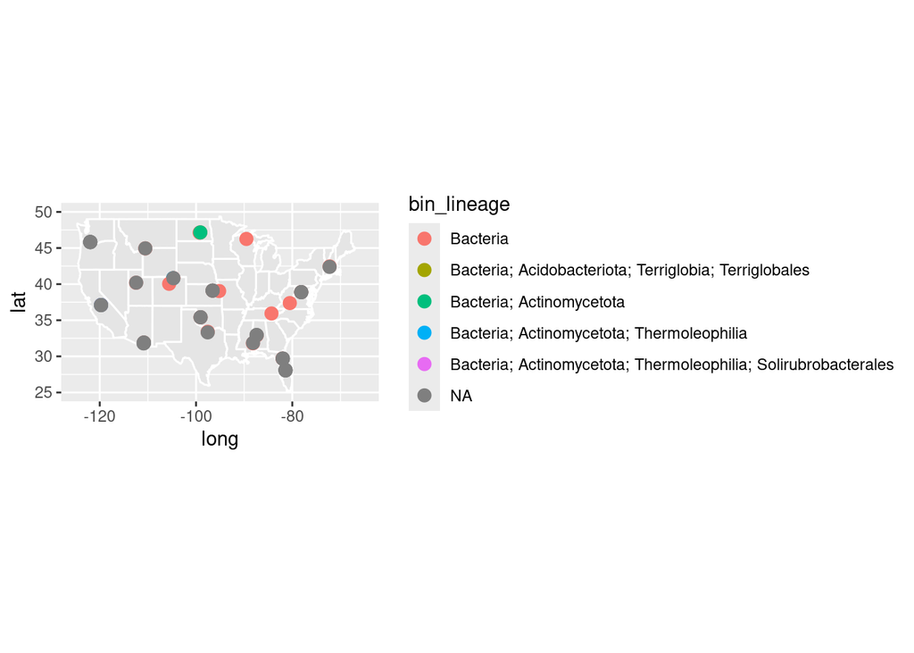

```r
library(ggplot2)
library(maps)

# Base map of the US (adjust region if needed)
us_map <- map_data("state")

ggplot() +
  geom_polygon(data = us_map, aes(x = long, y = lat, group = group),
               fill = "gray90", color = "white") +
  geom_point(data = dominant_species_by_site,
             aes(x = decimalLongitude, y = decimalLatitude, color = bin_lineage),
             size = 3) +
  coord_fixed(ratio=1.5) +
   xlim(-125, -65) +   # Wider longitude range for US
  ylim(25, 50)      # Latitude range
```

```r
  labs(title = "Dominant species by site",
       x = "Longitude", y = "Latitude", color = "Species") +
  theme_minimal()
```

```r
dominant_species_tRNA <- dominant_species_by_site %>%
  left_join(NEON_soilMAGs_soilChem %>%
              select(decimalLongitude, decimalLatitude, bin_lineage, t_rna_genes),
            by = c("decimalLongitude", "decimalLatitude", "bin_lineage"))
print(dominant_species_tRNA)
```

```
# A tibble: 524 × 6
# Groups:   site [32]
   site           decimalLatitude decimalLongitude bin_lineage count t_rna_genes
   <chr>                    <dbl>            <dbl> <chr>       <int>       <int>
 1 Caribou-Poker…            65.2            -148. <NA>            7          29
 2 Caribou-Poker…            65.2            -148. <NA>            7          35
 3 Caribou-Poker…            65.2            -148. <NA>            7          17
 4 Caribou-Poker…            65.2            -148. <NA>            7          49
 5 Caribou-Poker…            65.2            -148. <NA>            7          62
 6 Caribou-Poker…            65.2            -148. <NA>            7          62
 7 Caribou-Poker…            65.2            -148. <NA>            7          37
 8 Central Plain…            40.9            -105. Bacteria       24          20
 9 Central Plain…            40.9            -105. Bacteria       24          32
10 Central Plain…            40.9            -105. Bacteria       24          21
# ℹ 514 more rows
```

connecting tRNA with soil chemistry values (suggested by copilot)

Then, I wanted to associate tRNA with soil chemistry values. Co-pilot suggested this, and I thought that this would be a great connection to make, for tRNA provides insight into the amount of genes being expressed by the species. It would be interesting to see if certain aspects of the soil chemistry affected this. With further exploration (like somehow to look into what genes these tRNAs were translating to) it could provide insight into how the soil influences species composition.

```r
NEON_soilMAGs_soilChem_unique <- NEON_soilMAGs_soilChem %>%
  distinct(site, bin_lineage, .keep_all = TRUE)

dominant_species_tRNA <- dominant_species_by_site %>%
  left_join(NEON_soilMAGs_soilChem_unique %>%
              select(site, bin_lineage, t_rna_genes),
            by = c("site", "bin_lineage"))
```

```r
dominant_species_env <- dominant_species_by_site %>%
  left_join(NEON_soilMAGs_soilChem_unique %>%
              select(site, bin_lineage, t_rna_genes,
                     soilMoisture, soilTemp, soilInWaterpH, soilInCaClpH),
            by = c("site", "bin_lineage"))
print (dominant_species_env)
```

```
# A tibble: 76 × 10
# Groups:   site [32]
   site           decimalLatitude decimalLongitude bin_lineage count t_rna_genes
   <chr>                    <dbl>            <dbl> <chr>       <int>       <int>
 1 Caribou-Poker…            65.2           -148.  <NA>            7          36
 2 Central Plain…            40.9           -105.  Bacteria       24          20
 3 Central Plain…            40.8           -105.  Bacteria; …     4           8
 4 Central Plain…            40.8           -105.  Bacteria        4          24
 5 Central Plain…            40.8           -105.  Bacteria; …     4          16
 6 Chase Lake Na…            47.1            -99.3 Bacteria        7          41
 7 Dakota Coteau…            47.2            -99.1 Bacteria       13          53
 8 Dakota Coteau…            47.2            -99.1 Bacteria; …    13          17
 9 Delta Junctio…            63.9           -146.  Bacteria       14          52
10 Delta Junctio…            63.9           -146.  <NA>           14          39
# ℹ 66 more rows
# ℹ 4 more variables: soilMoisture <dbl>, soilTemp <dbl>, soilInWaterpH <dbl>,
#   soilInCaClpH <dbl>
```

This summarizes the data from above to connect the average tRNA and environemntal properties for the priamry bin_lineages.

```r
species_env_summary <- dominant_species_env %>%
  group_by(bin_lineage) %>%
  summarise(avg_trna = mean(t_rna_genes, na.rm = TRUE),
            avg_moisture = mean(soilMoisture, na.rm = TRUE),
            avg_temp = mean(soilTemp, na.rm = TRUE),
            avg_pH_water = mean(soilInWaterpH, na.rm = TRUE),
            avg_pH_CaCl = mean(soilInCaClpH, na.rm = TRUE),
            n_sites = n())
print (species_env_summary)
```

```
# A tibble: 6 × 7
  bin_lineage    avg_trna avg_moisture avg_temp avg_pH_water avg_pH_CaCl n_sites
  <chr>             <dbl>        <dbl>    <dbl>        <dbl>       <dbl>   <int>
1 Bacteria           37.4        0.393    19.7          5.98        5.38      26
2 Bacteria; Aci…     37          5.99      5.57         4.42        3.81       1
3 Bacteria; Act…     12.5        0.239    20.6          6.72        5.93       2
4 Bacteria; Act…     31          0.132    14.9          7.15        6.21       2
5 Bacteria; Act…     32          0.223     7.83         5.62        4.60       1
6 <NA>               37.6        0.194    23.2          6.94        6.86      44
```

```r
str(species_env_summary)
```

```
tibble [6 × 7] (S3: tbl_df/tbl/data.frame)
 $ bin_lineage : chr [1:6] "Bacteria" "Bacteria; Acidobacteriota; Terriglobia; Terriglobales" "Bacteria; Actinomycetota" "Bacteria; Actinomycetota; Thermoleophilia" ...
 $ avg_trna    : num [1:6] 37.4 37 12.5 31 32 ...
 $ avg_moisture: num [1:6] 0.393 5.99 0.239 0.132 0.223 ...
 $ avg_temp    : num [1:6] 19.7 5.57 20.65 14.92 7.83 ...
 $ avg_pH_water: num [1:6] 5.98 4.42 6.72 7.15 5.62 ...
 $ avg_pH_CaCl : num [1:6] 5.38 3.81 5.93 6.21 4.6 ...
 $ n_sites     : int [1:6] 26 1 2 2 1 44
```

```r
df <- species_env_summary %>%
  filter(!is.na(avg_trna), !is.na(avg_moisture))

cor.test(df$avg_trna, df$avg_moisture, method = "spearman")
```

```
    Spearman's rank correlation rho

data:  df$avg_trna and df$avg_moisture
S = 30, p-value = 0.8028
alternative hypothesis: true rho is not equal to 0
sample estimates:
      rho
0.1428571
```

```r
cor.test(
  as.numeric(species_env_summary[["avg_trna"]]),
  as.numeric(species_env_summary[["avg_moisture"]]),
  method = "spearman",
  use = "complete.obs"
)
```

```
    Spearman's rank correlation rho

data:  as.numeric(species_env_summary[["avg_trna"]]) and as.numeric(species_env_summary[["avg_moisture"]])
S = 30, p-value = 0.8028
alternative hypothesis: true rho is not equal to 0
sample estimates:
      rho
0.1428571
```

```r
species_env_summary <- dominant_species_env %>%
  group_by(bin_lineage) %>%
  summarise(
    avg_tRNA        = mean(as.numeric(t_rna_genes), na.rm = TRUE),
    avg_moisture    = mean(as.numeric(soilMoisture), na.rm = TRUE),
    avg_temp        = mean(as.numeric(soilTemp), na.rm = TRUE),
    avg_pH_water    = mean(as.numeric(soilInWaterpH), na.rm = TRUE),
    avg_pH_CaCl     = mean(as.numeric(soilInCaClpH), na.rm = TRUE),
    .groups = "drop"
  )
print (species_env_summary)
```

```
# A tibble: 6 × 6
  bin_lineage            avg_tRNA avg_moisture avg_temp avg_pH_water avg_pH_CaCl
  <chr>                     <dbl>        <dbl>    <dbl>        <dbl>       <dbl>
1 Bacteria                   37.4        0.393    19.7          5.98        5.38
2 Bacteria; Acidobacter…     37          5.99      5.57         4.42        3.81
3 Bacteria; Actinomycet…     12.5        0.239    20.6          6.72        5.93
4 Bacteria; Actinomycet…     31          0.132    14.9          7.15        6.21
5 Bacteria; Actinomycet…     32          0.223     7.83         5.62        4.60
6 <NA>                       37.6        0.194    23.2          6.94        6.86
```

```r
run_corr <- function(df, x, yvars) {
  results <- lapply(yvars, function(y) {
    xvec <- df[[x]]
    yvec <- df[[y]]

    # Only run if at least 2 finite values
    if(sum(is.finite(xvec) & is.finite(yvec)) >= 2) {
      test <- cor.test(xvec, yvec, method = "spearman", use = "complete.obs")
      data.frame(
        variable = y,
        correlation = test$estimate,
        p_value = test$p.value
      )
    } else {
      data.frame(variable = y, correlation = NA, p_value = NA)
    }
  })
  do.call(rbind, results)
}
```

```r
soil_vars <- c("avg_moisture", "avg_temp", "avg_pH_water", "avg_pH_CaCl")

corr_results <- run_corr(species_env_summary, "avg_tRNA", soil_vars)
print(corr_results)
```

```
         variable correlation   p_value
rho  avg_moisture  0.14285714 0.8027778
rho1     avg_temp  0.20000000 0.7138889
rho2 avg_pH_water -0.14285714 0.8027778
rho3  avg_pH_CaCl  0.08571429 0.9194444
```

Then to visualize the results of these correlation stats, a table was created.

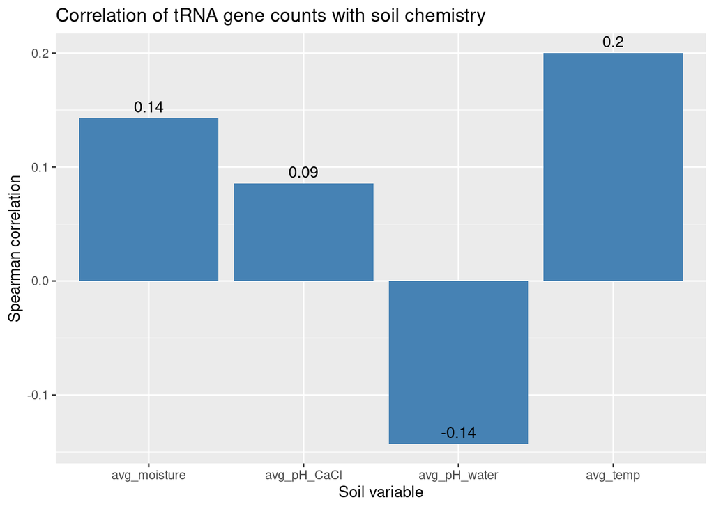

```r
ggplot(corr_results, aes(x = variable, y = correlation)) +
  geom_col(fill = "steelblue") +
  geom_text(aes(label = round(correlation, 2)), vjust = -0.5) +
  labs(title = "Correlation of tRNA gene counts with soil chemistry",
       x = "Soil variable", y = "Spearman correlation")
```

```r
 sum(is.na(species_env_summary$bin_lineage))
```

```
[1] 1
```

```r
species_env_summary <- species_env_summary %>%
  filter(!is.na(bin_lineage))
```

```r
species_env_summary <- species_env_summary %>%
  distinct(bin_lineage, .keep_all = TRUE)
```

```r
species_env_matrix <- species_env_summary %>%
  column_to_rownames("bin_lineage")
```

```r
species_env_matrix <- species_env_summary %>%
  select(bin_lineage, avg_tRNA, avg_moisture, avg_temp, avg_pH_water, avg_pH_CaCl) %>%
  column_to_rownames("bin_lineage")
```

```r
species_env_scaled <- scale(species_env_matrix)
```

A PCA analysis was run as another way to visualize the correlation between tRNA and soil composition and to map the dominant lineages onto it. I have never done a PCA analysis before so this also required some additional research. According to https://www.ibm.com/think/topics/principal-component-analysis, PCA analysis illustrates relationships between a few data points.

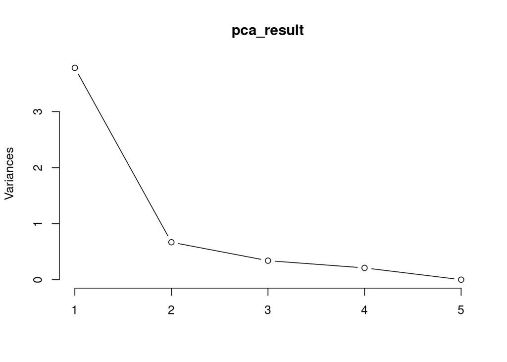

```r
pca_result <- prcomp(species_env_scaled, center = TRUE, scale. = TRUE)

# Scree plot
plot(pca_result, type = "l")
```

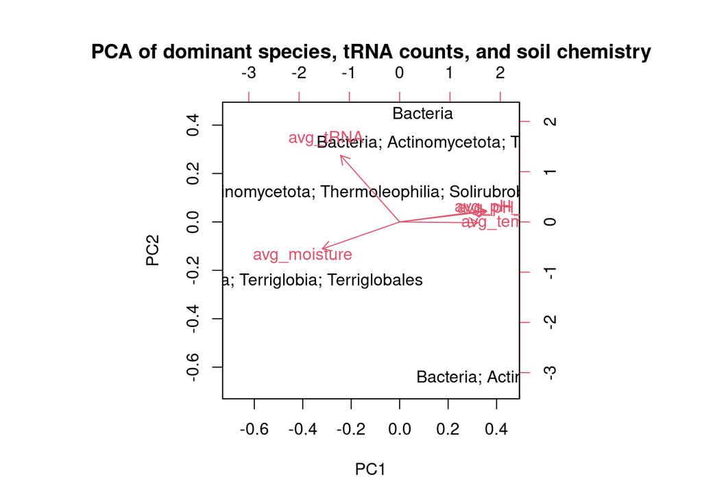

```r
# Biplot
biplot(pca_result, main = "PCA of dominant species, tRNA counts, and soil chemistry")
```

And finally, the results of the two previous graphs were essentially combined to create a graph of the dominant species also with the specific soil characteristics. Ai suggested that I perform an NMDS analysis, which I also was not familiar with. According to this site, https://library.virginia.edu/data/articles/starting-non-metric-multidimensional-scaling-nmds, it appears to serve almost the same purpose as the PCA analysis, for it decreases the amount of data pints to make predictions about the relationships between specific variables.

```r
library(vegan)
nmds_result <- metaMDS(species_env_scaled, distance = "euclidean", k = 2)
```

```
*** Best solution was not repeated -- monoMDS stopping criteria:
    15: stress < smin
     2: stress ratio > sratmax
     3: scale factor of the gradient < sfgrmin
```

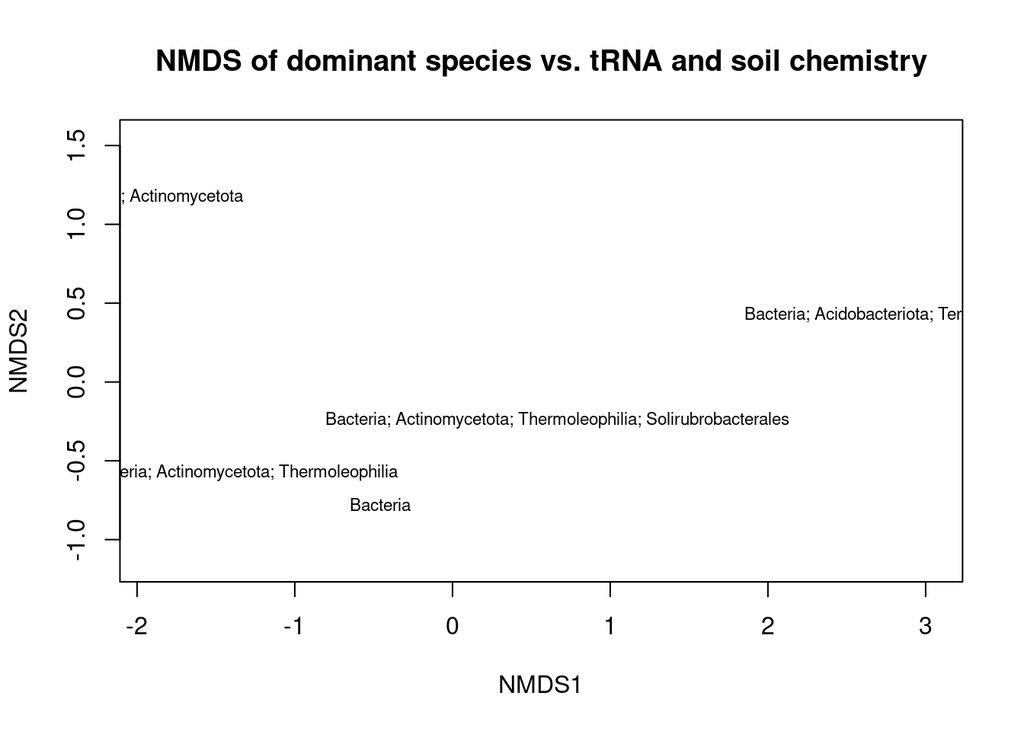

```r
plot(nmds_result, type = "t", main = "NMDS of dominant species vs. tRNA and soil chemistry")
```

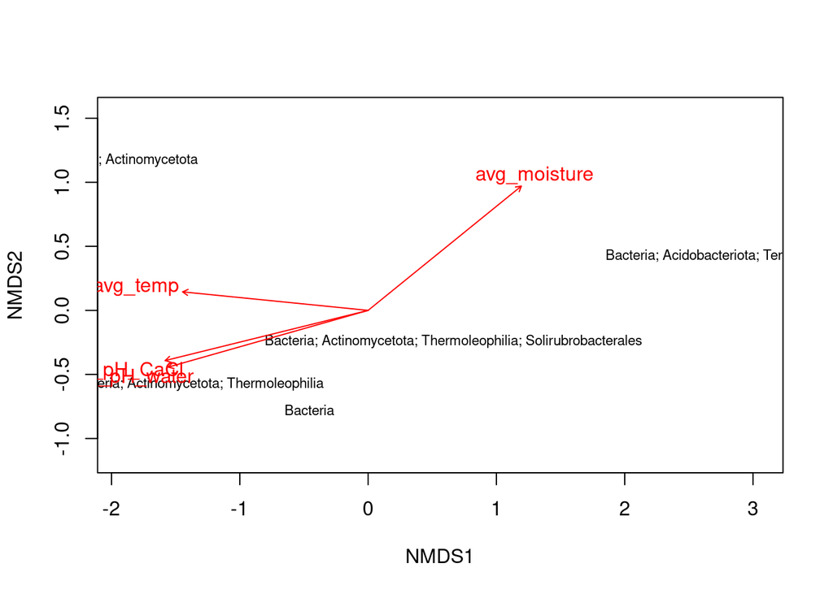

```r
envfit_result <- envfit(nmds_result ~ avg_moisture + avg_temp + avg_pH_water + avg_pH_CaCl,
                        data = species_env_summary, permutations = 999)

plot(nmds_result, type = "t")
plot(envfit_result, col = "red")  # arrows showing environmental gradients
```